# Chapter11: Sample Size Determination for Survival Studies

Deciding how many subjects to include in a randomized clinical trial is a key component of its design. In the classical hypothesis testing framework, for any type of outcome, one must specify the effect change one is aiming for, the inherent variability in the test statistic, the significance level of the test, and the desired power of the test to detect the effect change.

In survival analysis, there are additional factors that one must specify regarding the censoring mechanism and the particular survival distributions in the null and alternative hypotheses.  
First, one needs either to specify what parametric survival model one is using, or that the test will be semi-parametric, e.g., the log-rank test. This allows for determining the number of deaths (or events) required to meet the power and other design specifications.  
Second, one must, for administrative reasons, provide an estimate of the number of patients that need to be entered into the trial to produce the required number of deaths. We shall assume that the clinical trial is run as described in Chapter 1, where patients enter a trial over a certain accrual period of length *a*, and then followed for an additional period of time *f* known as the *follow-up time*. Patients still alive at the end of follow-up are censored. We will describe sample size methods for single arm clinical trials and then for two arm clinical trials.

### Power and Sample Size for a Single Arm Study

In a study with a single arm, we assume for planning purposes that the survival times follow an exponential distribution with hazard $h(t;\lambda)=\lambda$ and survival distribution $S(t, \lambda) = e^{-\lambda t}$.  
We shall test $H_0 : \lambda = \lambda_0$ versus $H_A : \lambda = \lambda_A$.  
The null hypothesis mean, $\mu_0 = 1/\lambda_0$, would correspond to the mean survival one has observed in the past for the standard therapy, and the alternative hazard, $\mu_A = 1/\lambda_A$ is a (presumably) larger mean survival that we aim to find with a new, experimental therapy.  
Thus, the treatment ratio we would like to detect may be written as $\Delta = \mu_A / \mu_0 = \lambda_0/\lambda_A$. After the trial is completed, we obtain a series ofindependentsurvivaltimes $t_1, t_2, t_3, \cdots, t_n$ and censoring indicators $\delta_1, \delta_2, \delta_3, \cdots, \delta_n$, where *n* is the total number of subjects in the trial.  
Our ultimate goal is to determine how many patients we need to detect a certain hazard ratio $\Delta$ with a specified power and significance level. The derivation of the formula is similar to that for tests concerning the mean of normally distributed observations, but some adjustments are needed to account for the presence of censoring.  
The main adjustment is that our sample size formula will directly specify $d$, the number of deaths needed to achieve the desired power. Once we have $d$, we use a separate method to find the number of patients $n$ needed to produce the required $d$.  
In practice, the null and alternative hypotheses may be expressed in terms of either median survival or survival probability at a specified time $t$. A median survival may be converted into a hazard rate by re-expressing $0.5 = e^{-\lambda t}$ as $\lambda = [\log(2)]/t$. Similarly, a survival rate $p$ at time $t$ may be written as $p=e^{-\lambda t}$, which may be expressed as $\lambda = -[\log(p)]/t$.  
These comparisons are strictly valid only if the survival distribution is exponential. However, for other survival distributions, the conversions between median survival and survival rates may provide reasonable approximations when survival rates are in the neighborhood of 50 %.  
The most direct way to derive a sample size formula is based on a Wald test, but the resulting formula varies depending on the parametrization of the likelihood. The simplest derivation uses the parameter $\theta = \log(\mu) = -\log(\lambda)$. Then we may express the log-likelihood function of Sect. 2.6 as follows:

$$l(\theta) = d \log(\lambda) - \lambda V= -\theta d - V e^{-\theta}$$
By following the development in Chapter2, the m.l.e. may be shown to be $\hat{\theta} = \log(V/d)$ and $var(\hat{\theta}) \approx 1/d$, where $d = \sum \delta_i$ and $V = \sum t_i$ are the number of deaths and the total patient-time, respectively.
We will use $\hat{\theta}$ as our test statistic, and reject $H_0$ in favor of $H_A$ if $\hat{\theta} > k$ for some constant $k$. The significant level of the test, or Type I error rate, is $\alpha = Pr(\hat{\theta} > k \ | \ \theta = \theta_0)$.
That is, the constant $k$ is chosen so that the probability of rejecting the null hypothesis is $\alpha$, assuming that the null hypothesis is true. Using a normalizing transformation.
$$Z = \frac{\hat{\theta}-\mu}{1/\sqrt{d}}$$
and hence
$$k = \theta_0 + \frac{z_{\alpha}}{\sqrt{d}}$$
Now let us consider what happens under the alternative hypothesis, where $\theta = \theta_A$. The *power* of the test is given by
$$1 - \beta = Pr(\hat{\theta} > k \ | \ \theta = \theta_A) = Pr(Z > \frac{k-\theta_A}{1/\sqrt{d}})$$
or equivalently,
$$z_{1-\beta} = -z_{\beta} = \sqrt{d} (k - \theta_A)$$
Substituting the value of k, we have
$$-z_{\beta} = \sqrt{d} (\theta_0 + \frac{z_{\alpha}}{\sqrt{d}} - \theta_A)$$
Solving for d we have
$$d = \frac{(z_{\beta} + z_{\alpha})^2}{(\theta_0 - \theta_A)^2}
= \frac{(z_{\beta} + z_{\alpha})^2}{(\log{\Delta})^2}$$
since $\log{(\Delta)} = \log{(\lambda_0)} - \log{(\lambda_A)}$.
This gives us **the number of deaths needed to achieve the specified power, not the number of patients**.
This derivation method is based on the parameter estimate normalized by its standard deviation, which produces the Wald test statistic. One aspect of this test is that different parametrizations lead to somewhat different formulas for the sample size. This dependence on parametrization may be largely avoided by working directly with the likelihood ratio statistic. Now, for fixed $d$, $V = \sum{t_i}$, has a gamma distribution with index $d$ and scale parameter $\lambda$. Cox and Oakes, following Epstein and Sobel, show that
$$W = \frac{2d\lambda}{\hat{\lambda}} \sim \chi^2_{2d}$$
although this result is approximate for general censoring patterns. Under $H_0:\lambda = \lambda_0$, we need to find a constant $k$ such that
$$\alpha = Pr(1/\hat{\lambda}>k \ | \ \lambda = \lambda_0) = Pr(W > 2kd\lambda_0)$$
and hence $\chi^2_{2d, \alpha} = 2kd\lambda_0$. Finally,
$$k=\frac{\chi^2_{2d, \alpha}}{2d\lambda_0}$$
The power of the test is given by
$$1-\beta=Pr(1/\hat{\lambda}>k \ | \ \lambda = \lambda_A) = Pr(W > 2kd\lambda_A)$$
where
$$k=\frac{\chi^2_{2d, 1 - \beta}}{2d\lambda_A}$$
Equating before Eqs, we have
$$\Delta = \frac{\lambda_0}{\lambda_A} = \frac{\chi^2_{2d, \alpha}}{\chi^2_{2d, 1 - \beta}}$$
For specified $\alpha$, power $1-\beta$, and ratio $\Delta$, we may solve this for the required number of deaths, $d$.

In R, we may compute the number of deaths using the following function:

```r
exp_log_mean_death <- function(delta, alpha, power){
  z_alpha <- qnorm(alpha, lower.tail = FALSE)
  z_beta <- qnorm(1 - power, lower.tail = FALSE)
  deaths <- (z_alpha + z_beta)^2 / (log(delta))^2
  return(deaths)
}
```

We use the `qnorm` function to compute $z_{\alpha}$ and $z_{\beta}$, and the final result is the number of deaths required to detect a hazard ratio $\Delta$ with significance level $\alpha$ and power $1-\beta$.

To use the likelihood ratio method, we first compute the hazard ratio $\Delta$ given $\alpha$, $1 - \beta$, and a specified number of deaths $d$ :

```r
exp_like_ratio <- function(deaths, alpha, power){
  num <- qchisq(alpha, df = (2 * deaths), lower.tail = FALSE)
  denom <- qchisq(power, df = (2 * deaths), lower.tail = FALSE)
  delta = num / denom
  return(delta)
}
```

Here we use the `qchisq` function to compute $\chi^2_{2d, \alpha}$ and $\chi^2_{2d, 1 - \beta}$.

To get the number of deaths d for a specified $\Delta$, we define a new function `LRD` internally which is zero at the required number of deaths:

```r
exp_LR_deaths <- function(delta, alpha, power){
  LRD <- function(x, alpha, power) {
    exp_like_ratio(x, alpha, power) - delta
  }
  result <- uniroot(f = LRD, lower = 1, upper = 1000, alpha = alpha, power = power)
  return(result$root)
}
```

Suppose that we are designing a Phase II oncology trial where we plan a **5 % level (one-sided) test**, and we need **80 % power** to detect a **hazard ratio of 1.5**.  
Once the above functions have been entered into R, we can find the required number of deaths as follows:

```r
# log mean method
exp_log_mean_death(1.5, 0.05, 0.8)
```

```
## [1] 37.60635
```

```r
# likelihood ratio method
exp_LR_deaths(1.5, 0.05, 0.8)
```

```
## [1] 36.33916
```

That is, we would need (rounding up) 38 deaths according to the log mean method (function `exp_log_mean_death`), and 37 deaths according to the likelihood ratio method (function `exp_LR_deaths`).  
The two methods give similar results over a wide range of specifications.

### Determining the Probability of Death in a Clinical Trial

In the previous section, we saw how to compute the required number of deaths to satisfy the power, significance, and survival difference design requirements of a trial.  
But as we have seen, in survival analysis, many subjects are still alive at the time of analysis. For administrative reasons, we usually need to specify how many patients need to be entered onto the trial, not how many will die. Thus, we need to provide an estimate of the proportion of patients who will die by the time of analysis.  
If all patients entered at the same time, we would simply have $\pi = 1 - S(t,\lambda)$, where $t$ is he follow-up time. However, patients actually enter over an accrual period of length $a$ and then, after accrual to the trial has ended, they are followed for an additional time $f$. So a patient who enters at time $t = 0$ will have failure probability $\pi(0) = 1 - S(a+f, \lambda)$, since a patient who enters at time will have the maximum possible follow-up time $a+f$. But a patient who enters at time a, which is the end of the accrual period, will have the minimum possible follow-up time f . Thus, that patient will have failure probability $\pi(a) = 1 - S(t,f)$. This is illustrated in Fig.

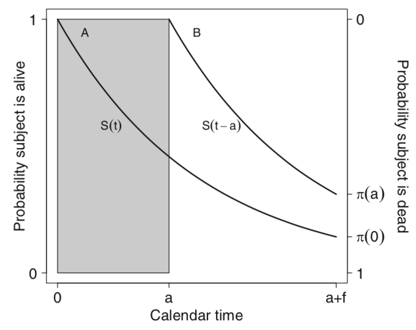

If patients were entered in equal numbers at times $0$ (curve A) or $a$ (curve B) only, then the probability of death would be $(\pi(0) + \pi(a))/2$. A much more realistic scenario is that the patients enter uniformly between times $0$ and $a$, so that the patient entry follows a Uniform($0$, $a$) distribution. Then the probability of death $\pi$ is obtained by averaging over these times, so that a patient that enters at time $t$ is followed for additional time $a + f - t$. This idea may be expressed by the following integral, which uses the fact that the probability of death given the patient enters at time $t$ is $1-S(a+f-t \ | \ \lambda)$,
$$\pi = \int^a_0 \frac{1}{a} Pr(death | enter \ at \ time \ t) dt$$
or just
$$\pi = \int^a_0 \frac{1}{a} (1-S(a+f-t \ | \ \lambda)) dt$$
Using the variable transformation $\mu = a+f-t$ and re-arranging, we have
$$\pi = \frac{1}{a} \int^{a+f}_{f} S(u;\lambda)dt$$
Since we are assuming an exponential distribution, we have $S(u;\lambda)=e^{-\lambda u}$, and we have, using basic integration,
$$\pi=1-\frac{1}{a}\int^{a+f}_{f}e^{-\lambda u}du=1-\frac{1}{a\lambda}\{ e^{-\lambda f}
-e^{-\lambda(a+f)} \}$$
The following function uses this expression to compute the probability of death:

```r
prob_death <- function(lambda, accrual, followup) {
  return(1 - (1 / (accrual * lambda)) * (exp(-lambda * followup) - exp(-lambda * (accrual + followup))))
}
```

```r
prob_death(lambda = 0.1, accrual = 2, followup = 3)
```

```
## [1] 0.3285622
```

Then the number of patients needed is approximately $38/0.3285622=115.6$, or 116 after rounding up.

```r
ceiling(exp_log_mean_death(delta = 1.5, alpha = 0.05, power = 0.8)) / prob_death(lambda = 0.1, accrual = 2, followup = 3)
```

```
## [1] 115.6554
```

This estimate depends critically not only on the assumption of an exponential distribution, but also on the unknown value of the exponential parameter $\lambda$. Using a specific value, such as $\lambda = 0.10$, is helpful in the planning stage of the trial, since administrators will need an estimate of the number of patients that will be needed. However, to maintain the integrity of the design, it would be preferable to tie the stopping rule for the trial to the number of deaths, 38, rather than to the estimated total number of patients, 116.

### Sample Size for Comparing Two Exponential Survival Distributions

We now consider a comparative clinical trial, where an experimental regimen is being compared to a standard, control regimen. Suppose that we are going to test the null hypothesis $H_0:S_0 \geq S_1$ versus the alternative $S_0 < S_1$ for all $t$, where $S_0$ and $S_1$ are exponential survival distributions with hazards $\lambda_0$ and $\lambda_1$, for the control and experimental regimens, respectively. To determine the required sample size, we consider the hazard ratio $\Delta = \lambda_0 / \lambda_1$.
Now $\lambda_0$ and $\lambda_1$ are the hazards for a control and experimental treatments, and we presume that the latter hazard is the smaller one, and that our test may be viewed as the one-sided test of $H_0:\Delta = 1$ versus $H_1:\Delta > 1$. This well-known case was developed by Bernstein and Lagakos, Rubenstein et al. and others.
We let $p$ denote the proportion of patients randomized to the control group. Typically one uses equal randomization, so that $p=0.5$, but this is not required. We denote by $n$ the total number of patients in the trial, and we have $n_0=np$ and $n_1=n(1-p)$ control and experimental patients, respectively.
When the trial has been completed, we will observe $d_0$ and $d_1$ deaths in the control and experimental groups, and total patient times of $V_0=\sum t_{0i}$ and $V_1=\sum t_{1i}$, respectively. We know from Sect 2 that the maximum likelihood estimates of the hazards are $\hat{\lambda_0} = d_0/V_0$ and $\hat{\lambda_1} = d_1/V_1$.
To compare the two distributions, it is more convenient to use $\delta = \log{\Delta} = \log{\lambda_0}-\log{\lambda_1}$, since the log scale transformed value will be more symmetric. One may show that, based on maximum likelihood theory,
$$var(\hat{\delta})=\sigma^{2}=(\frac{1}{E(d_0)}+\frac{1}{E(d_1)})=
\frac{1}{n_0\pi_0}+\frac{1}{n_1\pi_1}=\frac{1}{np(1-p)}\cdot\frac{p\pi_0+(1-p)\pi_1}{\pi_0\pi_1}$$

### Sample Size for Comparing Two Survival Distributions Using the Log-Rank Test

When the data from a completed comparative clinical trial are analyzed, typically one uses a log-rank test rather than a test based on the exponential distribution, for reasons discussed in Chapter 3. Thus, it would seem reasonable to develop a sample size formula based on the log-rank test.  
With this test, which is based on the proportional hazards assumption, the ratio $\Delta = \lambda_0(t)/\lambda_1(t)$ is constant, but the baseline hazard $\lambda_0(t)$ is unspecified.

We then use the log-rank statistics $U_0$ and its variance, which for the $i$th failure time is given by
$$v_{0i}=var(d_{0i})=\frac{n_{0i}n_{1i}d_i(n_i-d_i)}{n_i^2(n_i-1)}$$
As explained in Chapter 3, these are also the score function of the partial likelihood and its variance. Assuming that the number of deaths at each failure time is small compared to the number at risk, and that the proportion $p \approx n_{01}/n_{1i}$ of subjects assigned to the control group is constant over time, we have the following approximation,
$$v_{0i}=var(d_{0i})=\frac{n_{0i}n_{1i}d_i(n_i-d_i)}{n_i^2(n_i-1)}
\approx \frac{n_{0i}n_{1i}d_i}{n_i^2} \approx p(1-p)d_i$$
The variance of the log-rank statistic is then approximately
$$V_0=\displaystyle \sum^{D}_{i=1} v_{0i} \approx
p(1-p)\sum^{D}_{i=1} d_i=p(1-p)d$$
Then using a standard sample size and power calculation (see Collett and Schoenfeld for details), we find that the number of events needed to detect a treatment difference $\delta=\log(\lambda_0(t)/\lambda_1(t))=\log\Delta$ with power $1-\beta$ and with a two-sided level $\alpha$ log-rank test, is identical to that given in Eq. 11.3.2.
$$d=\frac{(z_{\alpha/2}+z_{\beta})^2}{p(1-p)\delta^2}$$
or, if the same number of patients are in both groups, by
$$d=\frac{(z_{\alpha/2}+z_{\beta})^2}{\delta^2/4}$$
As in previous cases, this formula gives us the required number of deaths (or events), not the number of patients. Estimating the number of patients that are needed requires and estimate of the probability of death, as we saw in Sect. 11.3.

### Determining the Probability of Death from a Non-parametric Survival Curve Estimate

One way of determining the number of patients needed to produce a particular number of deaths is to assume that patients enter uniformly over the accrual period, and that survival is governed by an exponential distribution. Then we can proceed as in Sect. 11.2.
However, if a survival distribution estimate is available for the control group, say, from an earlier trial, then we can use that, along with the proportional hazards assumption, to estimate a probability of death without assuming that the survival distribution is exponential.
Typically, the survival function for the control group of a randomized trial is a Kaplan-Meier estimate $\hat{S_0} (t)$ obtained from a prior study. If we need to detect a hazard ratio $\Delta$, the alternative hypothesis survival function will be, assuming proportional hazards,
$$\hat{S_1} (t) = [\hat{S_0} (t)]^{1/\Delta}$$
Then to compute the expected number of deaths with accrual and followup times $a$ and $f$, we use the weighted mean survival,
$$\hat{S} (t) = p\hat{S_0} (t) + (1-p) \hat{S_1} (t)$$
where $p$ is the proportion of subjects randomly assigned to the control group.
Given a survival function $\hat{S}(t)$ here are a number of ways of evaluating the integral in Eq. 11.2.2.
In most cases we may obtain a good approximation of the integral by evaluating $\hat{S}(t)$ for a patient entering at time $0$, $a/2$, and $a$, and use some results from elementary integral calculus.
One simple approach is the trapezoidal rule, which uses the areas under two trapezoids defined by the time points $0$, $a/2$, and $a$ and values that match the integrand at these points. This yields an estimate of the probability of death given by
$$\pi_t \approx 1-\frac{1}{4} \{\hat{S}(a+f)+2\hat{S}(\frac{a}{2}+f)+\hat{S}(f)\}$$
Alternatively, we can use Simpson’s rule, which uses the area under a quadratic polynomial that matches the integrand at these three points. The underlying algebra is a bit tedious, but the well-known end result is quite simple:
$$\pi_s \approx 1-\frac{1}{6} \{\hat{S}(a+f)+4\hat{S}(\frac{a}{2}+f)+\hat{S}(f)\}$$
The most accurate method is to evaluate the integral numerically. Since the survival estimate $\hat{S}(t)$, a weighted mean of $\hat{S_0} (t)$ and $\hat{S_1}(t)$, is a step function, the integral may be written as a sum of areas of rectangles under each “step” at the failure times between $a$ and $a+f$.
To do this we denote all of the ordered failure times by $t_{(1)},t_{(2)}, ...,t_{(n)}$. Then the integral in Eq. 11.2.2 may be estimated as follows:
$$\pi_{r}=\displaystyle \sum_{t_{(i)}:f<t_{(i)}\leq f+a} [\hat{S}(a+f-t_{(i)})\cdot(t_{(i)}-t_{(i-1)})]$$
We may illustrate estimating $\pi$ using the data `gastricXelox`. This figure illustrates this.

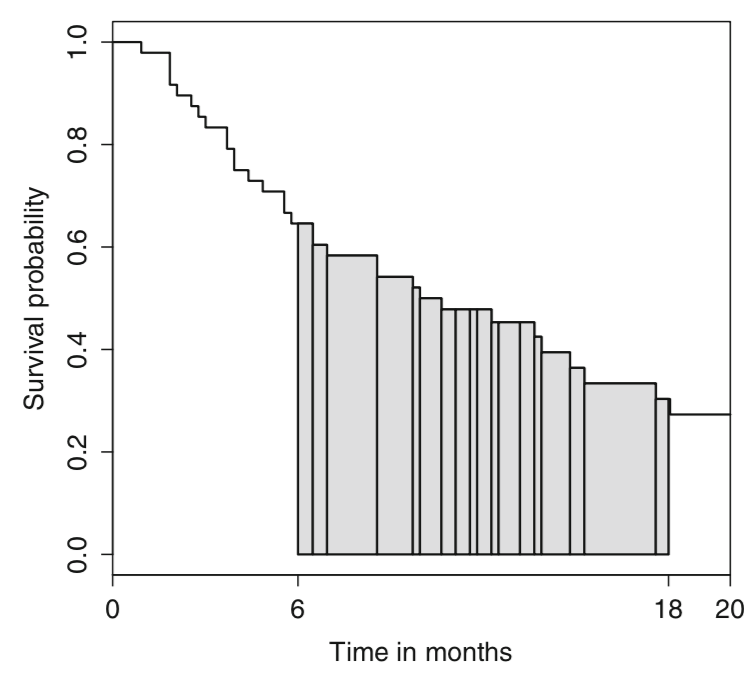